# Assignment 6

In this assignment, you'll analyze a collection of data sets from the [San Francisco Open Data Portal](http://data.sfgov.org/) and [Zillow](https://www.zillow.com/). The data sets have been stored in the SQLite database `sf_data.sqlite`, which you can [download here](http://anson.ucdavis.edu/~nulle/sf_data.sqlite). The database contains the following tables:

| Table | Description |
| --- | --- |
| `crime` | Crime reports dating back to 2010. |
| `mobile_food_locations` | List of all locations where mobile food vendors sell. |
| `mobile_food_permits` | List of all mobile food vendor permits. More details [here](https://data.sfgov.org/api/views/rqzj-sfat/files/8g2f5RV4PEk0_b24iJEtgEet9gnh_eA27GlqoOjjK4k?download=true&filename=DPW_DataDictionary_Mobil… |
| `mobile_food_schedule` | Schedules for mobile food vendors. |
| `noise` | Noise complaints dating back to August 2015. |
| `parking` | List of all parking lots. |
| `parks` | List of all parks. |
| `schools` | List of all schools. |
| `zillow` | Zillow rent and housing statistics dating back to 1996. More details [here](https://www.zillow.com/research/data/). |

The `mobile_food_` tables are explicitly connected through the `locationid` and `permit` columns. The other tables are not connected, but you may be able to connect them using dates, latitude/longitude, or postal codes.

Shapefiles for US postal codes are available [here](https://www.census.gov/geo/maps-data/data/cbf/cbf_zcta.html). These may be useful for converting latitude/longitude to postal codes.

Shapefiles for San Francisco Neighborhoods are available [here](https://data.sfgov.org/Geographic-Locations-and-Boundaries/SF-Find-Neighborhoods/pty2-tcw4).

**Exercise 1.1.** Which mobile food vendor(s) sells at the most locations?

```python
import pandas as pd
from matplotlib import pyplot as plt
import sqlalchemy as sqla
import sqlite3 as sql
%matplotlib inline
plt.style.use('ggplot')
```

```python
db = sql.connect("sf_data.sqlite")
cursor = db.execute("SELECT * FROM sqlite_master")
#cursor.fetchall()
```

```python
pd.read_sql("""
            SELECT Applicant, COUNT(DISTINCT(locationid)) AS LocationCount
            FROM mobile_food_permits,
                (SELECT *
                FROM mobile_food_locations, mobile_food_schedule
                WHERE mobile_food_locations.locationid = mobile_food_schedule.locationid) as m1
            WHERE m1.permit = mobile_food_permits.permit
            GROUP BY Applicant
            ORDER BY COUNT(DISTINCT(locationid)) DESC
            LIMIT 10;""", db)
```

|  | Applicant | LocationCount |
| --- | --- | --- |
| 0 | May Catering | 58 |
| 1 | Anas Goodies Catering | 37 |
| 2 | Natan's Catering | 37 |
| 3 | Liang Bai Ping | 33 |
| 4 | Park's Catering | 23 |
| 5 | Singh Brothers Ice Cream | 21 |
| 6 | John's Catering #5 | 19 |
| 7 | Mang Hang Catering | 19 |
| 8 | Sun Rise Catering | 19 |
| 9 | D & T Catering | 17 |

So May Catering sells at the most locations with 58 unique places.

**Exercise 1.2.** Ask and use the database to analyze 5 questions about San Francisco. For each question, write at least 150 words and support your answer with plots. Make a map for at least 2 of the 5 questions.

You should try to come up with some questions on your own, but these are examples of reasonable questions:

- Which parts of the city are the most and least expensive?
- Which parts of the city are the most dangerous (and at what times)?
- Are noise complaints and mobile food vendors related?
- What are the best times and places to find food trucks?
- Is there a relationship between housing prices and any of the other tables?

Please make sure to clearly state each of your questions in your submission.

```python
from mpl_toolkits.basemap import Basemap
import numpy as np
import geopandas as gpd
import shapely.geometry as geom
from matplotlib.collections import PatchCollection
%matplotlib inline
import matplotlib.cm
from matplotlib.patches import Polygon
from matplotlib.colors import Normalize
import matplotlib.pyplot as plt
plt.rcParams['figure.figsize'] = (9, 9)
```

**Question 1: Do food vendors sell near parks or Schools?**

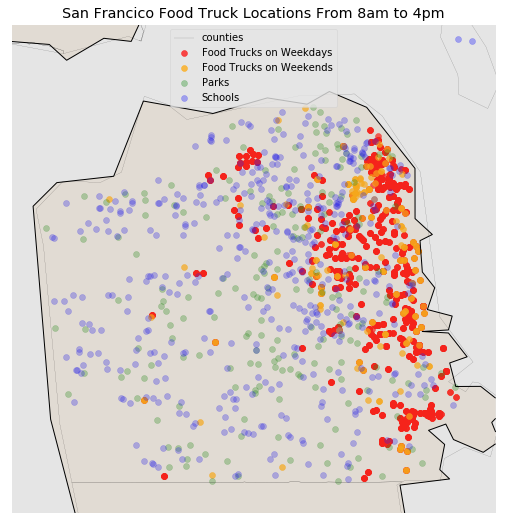

```python
foodLonLat = pd.read_sql("""SELECT Info.Latitude AS Lat, Info.Longitude AS Lon
               FROM ( SELECT *
                      FROM mobile_food_locations, mobile_food_schedule
                      WHERE mobile_food_locations.locationid = mobile_food_schedule.locationid ) AS Info
               WHERE EndHour < 17 AND StartHour > 7 AND DayOfWeek <> 'Sa' AND DayOfWeek <> 'Su';""", db) # School days and hours
foodLonLat2 = pd.read_sql("""SELECT Info.Latitude AS Lat, Info.Longitude AS Lon
               FROM ( SELECT *
                      FROM mobile_food_locations, mobile_food_schedule
                      WHERE mobile_food_locations.locationid = mobile_food_schedule.locationid ) AS Info
               WHERE EndHour < 17 AND StartHour > 7 AND DayOfWeek = 'Sa' OR DayOfWeek = 'Su';""", db) # School hours and weekend
parksLonLat = pd.read_sql("""SELECT Lat, Lon
                             FROM parks;""", db)
schoolsLonLat = pd.read_sql("""SELECT Lat, Lon
                             FROM schools;""", db)
myMap = Basemap(llcrnrlon=-122.523, llcrnrlat=37.7, urcrnrlon=-122.36, urcrnrlat=37.83, resolution="h",
    projection="merc") # Need to zoom in some
myMap.drawcoastlines()
myMap.drawcounties()
myMap.fillcontinents(color='tan',lake_color='aqua', alpha = 0.2)
myMap.scatter(foodLonLat.Lon.values, foodLonLat.Lat.values, color = "red", latlon = True, alpha = 0.7, label = "Food Trucks on Weekdays")
myMap.scatter(foodLonLat2.Lon.values, foodLonLat2.Lat.values, color = "orange", latlon = True, alpha = 0.7, label = "Food Trucks on Weekends")
myMap.scatter(parksLonLat.Lon.values, parksLonLat.Lat.values, color = "green", latlon = True, alpha = 0.3, label = "Parks")
myMap.scatter(schoolsLonLat.Lon.values, schoolsLonLat.Lat.values, color = "blue", latlon = True, alpha = 0.3, label = "Schools")
plt.title("San Francico Food Truck Locations From 8am to 4pm")
plt.legend()
```

To answer this question I plotted the location of food trucks that start between 8 AM and 4 PM in red and orange on a map of San Francisco. I picked these hours because we are interested in parks and schools which are mostly used during the day. The red trucks are truck locations on weekdays, so days kids would be in school. The orange trucks are truck locations on weekend, when parks are used a lot, but schools are not. The green dots are park locations and the blue dots are school locations. Looking at the map, schools and parks are scattered all around San Francisco, but food trucks are mostly clustered on the East side. There is some overlap with food trucks and park and school locations, but there are also many chunks of red and orange with no blue or green nearby. The locations do not differ that much for weekday versus weekend. So, from this map, I would say that food trucks can be located near parks and schools, but they do not appear to pick locations based around them.

**Question 2: What are the most common types of crimes and where do these types fall on a map?**

To answer the first part of this question I just used SQL to grab the five most common types. I decided on five because I am going to plot each one on the map in a different color and too many colors could get crazy.

```python
pd.read_sql("""SELECT COUNT(*) AS Count, Category
               FROM crime
               GROUP BY Category
               ORDER BY COUNT(*) DESC
               LIMIT 5""", db)
```

|  | Count | Category |
| --- | --- | --- |
| 0 | 243144 | LARCENY/THEFT |
| 1 | 141431 | OTHER OFFENSES |
| 2 | 125702 | NON-CRIMINAL |
| 3 | 90029 | ASSAULT |
| 4 | 54467 | VANDALISM |

So now we can see that the top crime is larceny/theft followed by other offenses and so on. Two of these top categories do not actually tell us much about the crime, which is not ideal. Other offenses could be anything that does not fit into the category options and non-criminal is very vague. Plotting each of these on the map gives:

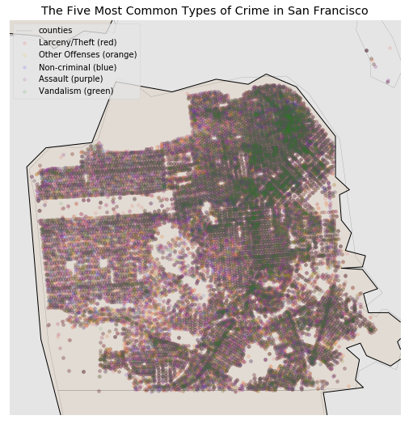

```python
theft = pd.read_sql("""SELECT DISTINCT Lat, Lon FROM crime WHERE category = 'LARCENY/THEFT'""", db)
other = pd.read_sql("""SELECT DISTINCT Lat, Lon FROM crime WHERE category = 'OTHER OFFENSES'""", db)
nonCrime = pd.read_sql("""SELECT DISTINCT Lat, Lon FROM crime WHERE category = 'NON-CRIMINAL'""", db)
assault = pd.read_sql("""SELECT DISTINCT Lat, Lon FROM crime WHERE category = 'ASSAULT'""", db)
vandalism = pd.read_sql("""SELECT DISTINCT Lat, Lon FROM crime WHERE category = 'VANDALISM'""", db)

myMap = Basemap(llcrnrlon=-122.523, llcrnrlat=37.7, urcrnrlon=-122.36, urcrnrlat=37.83, resolution="h",
    projection="merc")
myMap.drawcoastlines()
myMap.drawcounties()
myMap.fillcontinents(color='tan',lake_color='aqua', alpha = 0.2)

myMap.scatter(theft.Lon.values, theft.Lat.values, color = "red", latlon = True, alpha = 0.1, label = "Larceny/Theft (red)", s = 15)
myMap.scatter(other.Lon.values, other.Lat.values, color = "orange", latlon = True, alpha = 0.1, label = "Other Offenses (orange)", s = 15)
myMap.scatter(nonCrime.Lon.values, nonCrime.Lat.values, color = "blue", latlon = True, alpha = 0.1, label = "Non-criminal (blue)", s = 15)
myMap.scatter(assault.Lon.values, assault.Lat.values, color = "purple", latlon = True, alpha = 0.1, label = "Assault (purple)", s = 15)
myMap.scatter(vandalism.Lon.values, vandalism.Lat.values, color = "green", latlon = True, alpha = 0.1, label = "Vandalism (green)", s = 15)

plt.title("The Five Most Common Types of Crime in San Francisco")
plt.legend()
```

Since the data has so many incidences of crime, the plot has a lot of overlap even with a small alpha. The order the points were plotted affects the result. But, the plot still tells us that the top five crimes in the city happen in around the same areas. The most crimes happen in the northeast side of the city. Within the top five crimes, location does not change much.

**Question 3: How is the parking near food trucks?**

Considering that food trucks do not have their own parking lots, or really places they can park, I am interested in if there locations are near parking lots or garages.

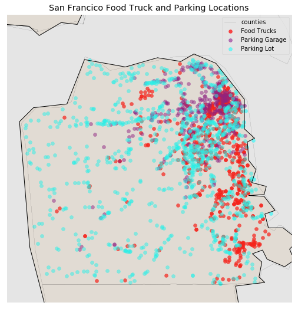

```python
parkingG = pd.read_sql("SELECT Lat, Lon, RegCap FROM parking WHERE GarOrLot = 'G'", db)
parkingL = pd.read_sql("SELECT Lat, Lon, RegCap FROM parking WHERE GarOrLot = 'L'", db)
foodTrucks = pd.read_sql("SELECT Latitude AS Lat, Longitude AS Lon FROM mobile_food_locations", db)

myMap = Basemap(llcrnrlon=-122.523, llcrnrlat=37.7, urcrnrlon=-122.36, urcrnrlat=37.83, resolution="h",
    projection="merc")
myMap.drawcoastlines()
myMap.drawcounties()
myMap.fillcontinents(color='tan',lake_color='aqua', alpha = 0.2)

myMap.scatter(foodTrucks.Lon.values, foodTrucks.Lat.values, color = "red", latlon = True, alpha = 0.7, label = "Food Trucks")
myMap.scatter(parkingG.Lon.values, parkingG.Lat.values, color = "purple", latlon = True, alpha = 0.5, label = "Parking Garage")
myMap.scatter(parkingL.Lon.values, parkingL.Lat.values, color = "aqua", latlon = True, alpha = 0.5, label = "Parking Lot")
plt.title("San Francico Food Truck and Parking Locations")
plt.legend()
```

Throughout the city, there are a lot more parking lots than garages. Most of the parking lots are located in that northeast side of the city that seems to be where most of the action is. Some food trucks are very close to parking lots and garages, but there are also a bunch that are not close to either. In the big clump of points near the right upper corner of the map, there is a lot overlap of food trucks and parking lots. Overall, it does not appear that food trucks pick their location based on parking lots and garages. For a person seeking out food from a food truck, parking is easier for some than others. They should look up the parking availability before setting their taste buds on a specific truck. Or just be willing to street park, take Bart, or walk.

**Question 4: Where in San Francisco are the highest priced houses?**

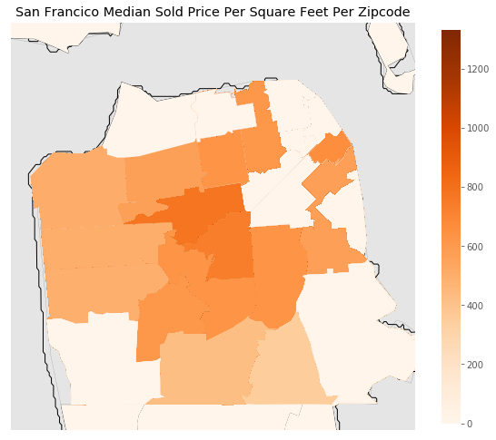

```python
fig, ax = plt.subplots(figsize=(10,20))
housing = pd.read_sql("SELECT RegionName AS GEOID10, MedianSoldPricePerSqft_AllHomes FROM zillow", db)

myMap = Basemap(llcrnrlon=-122.523, llcrnrlat=37.7, urcrnrlon=-122.36, urcrnrlat=37.83, resolution="f",
    projection="merc")
myMap.drawcoastlines()
myMap.drawcounties()
myMap.readshapefile("cb_2015_us_zcta510_500k", "zipcodes")

zips = gpd.read_file("cb_2015_us_zcta510_500k.shp")
#zips = zips[zips.ZCTA5CE10.str.startswith("9")]
#zips = zips[pd.to_numeric(zips.GEOID10) <= 96199]

zips = pd.DataFrame({
        'shapes': [Polygon(np.array(shape), True) for shape in myMap.zipcodes],
        'GEOID10': [int(zipcode['GEOID10']) for zipcode in myMap.zipcodes_info] })

zips = zips.merge(housing, on = "GEOID10", how = "left")

cmap = plt.get_cmap('Oranges')
pc = PatchCollection(zips.shapes, zorder = 2)
norm = Normalize()
pc.set_facecolor(cmap(norm(zips['MedianSoldPricePerSqft_AllHomes'].fillna(0).values)))
ax.add_collection(pc) # was ax.

mapper = plt.cm.ScalarMappable(norm=norm, cmap=cmap)
mapper.set_array(zips['MedianSoldPricePerSqft_AllHomes'])
plt.colorbar(mapper, shrink=0.4)

plt.title("San Francico Median Sold Price Per Square Feet Per Zipcode")
```

To answer this question, I decided to separate the housing price for each zip code. Each zip code region on the map has a shade of orange corresponding to the median sold price per square foot for all of the sold houses in that zip code. The darker the color, the higher the median sold price. So the most expensive houses are in the middle of San Francisco. A lot of the lower priced houses are on the edge of San Francisco, which seems strange considering that an ocean view should increase the price. This might just be how it is, or this might because the zillow table is missing data on the median house price for some zip codes. This could also just be because living the middle of the city is more expensive. There might be a lot happening with restaurants and shops that you pay more to be able to walk to.

**Question 5: What areas of San Francisco have the most noise complaints?**

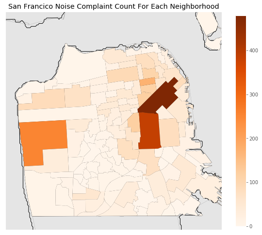

```python
fig, ax = plt.subplots(figsize=(10,20))
noise = pd.read_sql("SELECT COUNT(*) as Count, Neighborhood FROM noise WHERE Neighborhood <> 'None' GROUP BY Neighborhood", db)

myMap = Basemap(llcrnrlon=-122.523, llcrnrlat=37.7, urcrnrlon=-122.36, urcrnrlat=37.83, resolution="f",
    projection="merc")
myMap.drawcoastlines()
myMap.drawcounties()
myMap.readshapefile("geo_export_c540f0fb-6194-47ad-9fa9-12150ac3dd4c", "noises")

neighs  = gpd.read_file("geo_export_c540f0fb-6194-47ad-9fa9-12150ac3dd4c.shp")

neighs = pd.DataFrame({
        'shapes': [Polygon(np.array(shape), True) for shape in myMap.noises],
        'Neighborhood': [n['name'] for n in myMap.noises_info] })

neighs = neighs.merge(noise, on = "Neighborhood", how = "left")

cmap = plt.get_cmap('Oranges')
pc = PatchCollection(neighs.shapes, zorder = 2)
norm = Normalize()
pc.set_facecolor(cmap(norm(neighs['Count'].fillna(0).values)))
ax.add_collection(pc) # was ax.

mapper = plt.cm.ScalarMappable(norm=norm, cmap=cmap)
mapper.set_array(neighs['Count'])
plt.colorbar(mapper, shrink=0.4)

plt.title("San Francico Noise Complaint Count For Each Neighborhood")
```

To answer the question, I plotted all of the San Francisco neighborhoods on the map and shaded each one based on the count of noise complaints within that neighborhood. The darker the shade of orange, the more noise complaints. There are three neighborhoods that clearly have more noise complaints than the rest. One is located mid-left and the other two are located in the middle/top right. To see which neighborhoods these are I used SQL and the result is below. Overall, a lot of the neighborhoods do not have very many noise complaints. Size of each neighborhood is probably somewhat a factor. The three noisiest ones are on the larger side, but there are also some large neighborhoods with no noise complaints. Especially that large neighborhood near the top of the map and the large one in the bottom left corner.

```python
pd.read_sql("SELECT COUNT(*) as Count, Neighborhood FROM noise WHERE Neighborhood <> 'None' GROUP BY Neighborhood ORDER BY COUNT(*) DESC LIMIT 3", db)
```

|  | Count | Neighborhood |
| --- | --- | --- |
| 0 | 480 | South of Market |
| 1 | 386 | Mission |
| 2 | 254 | Outer Sunset |

So the loudest neighborhoods are South of Market, Mission, and Outer Sunset.

```python
db.close()
```